# Data Extraction in Python

## SQL

The exercises in this section are based on the university database from the Database System Concepts.

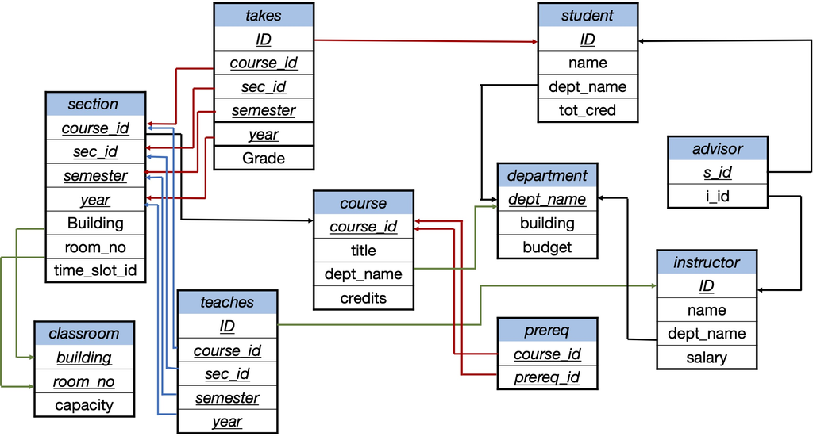

University database

**Writing SQL queries with aggregate functions**

1. Write a query to return the names of students with the largest and smallest number of `tot_cred`.

```sql
  SELECT name FROM student
  WHERE tot_cred = (Select max(tot_cred) from student)
  OR tot_cred = (Select min(tot_cred) from student);
```

```sql
SELECT DISTINCT dept_name
FROM (SELECT dept_name, count(*) AS num_students FROM student GROUP BY dept_name)
WHERE num_students > 1
```

3. Write a query to return the number of students in the Comp. Sci., Physics, Finance and History.

```sql
  SELECT dept_name, num_students FROM
  (SELECT dept_name, count (*) num_students FROM student S GROUP BY S.dept_name )
  WHERE dept_name IN ('Comp. Sci.', 'Physics', 'Finance', 'History');
```

We can even write a simpler query using HAVING since we have GROUP BY. We can rewrite the query as:

```sql
  SELECT dept_name, count (*) num_students
  FROM student S GROUP BY S.dept_name
  HAVING dept_name IN ('Comp. Sci.', 'Physics', 'Finance', 'History');
```

## Python

In the following exercises, you will practice on working Pandas dataframes and how to extract part of the data using Python APIs. You will also practice on connecting to an `SQLite` database, send `SQL` queries, and extract the results to a Pandas dataframe. There are parts where the code is available so you need to run the code, understand and comment on the output. There are also a set of exercises where you need to write the code yourself.

First, we need to import the libraries that are required for our code. You can run the code on Google Colab or using your favorite IDE for Python.

```python
import pandas as pd
import csv
```

Run the code and comment on the output. After that, solve the exercises with the TODO.

### Creating dataframes

**creating a dataframe from pandas series**

```python
data = {'State': ['Ohio', 'Ohio', 'Ohio', 'Nevada', 'Nevada', 'Nevada'],
 'Year': [2000, 2001, 2002, 2001, 2002, 2003],
 'Population': [1.5, 1.7, 3.6, 2.4, 2.9, 3.2]}
df = pd.DataFrame(data)
df
```

**creating a dataframe from data matrix**

```python
data = [['Ohio', 2000, 1.5], ['Ohio', 2001, 1.7], ['Ohio', 2002, 3.6],
        ['Nevada', 2001, 2.4],['Nevada', 2002, 2.9], ['Nevada', 2003, 3.2]]
cols = ['State', 'Year', 'Population']
df = pd.DataFrame(data, columns = cols)
df
```

**printing the number of columns and the number of rows in a dataframe**

```python
print("number of columns = ", len(df.columns))
print('number of rows = ', len(df))
```

**creating a dataframe using data stored in a csv file**

```python
df = pd.read_csv(filepath_or_buffer = 'sample_data/california_housing_train.csv',
                 delimiter=',', doublequote=True, quotechar='"',
                 na_values = ['na', '-', '.', ''],
                 quoting=csv.QUOTE_ALL, encoding = "ISO-8859-1")
df
```

You may also use your own dataset or the movies dataset.

**Extracting columns (attributes), rows or blocks of data**

- Extracting rows and blocks

```python
df.info() # index & data types
n = 4
dfh = df.head(n)             # get first n rows
dft = df.tail(n)             # get last n rows
top_left_corner_df = df.iloc[:5, :5]
```

```python
# TODO: display the content of dfh, dft, top_left_corner_df
```

You can display the content of dfh, dft, top_left_corner_df using:

```python
dfh, dft, top_left_corner_df
```

However, the output will be hard to read. The output will be like:

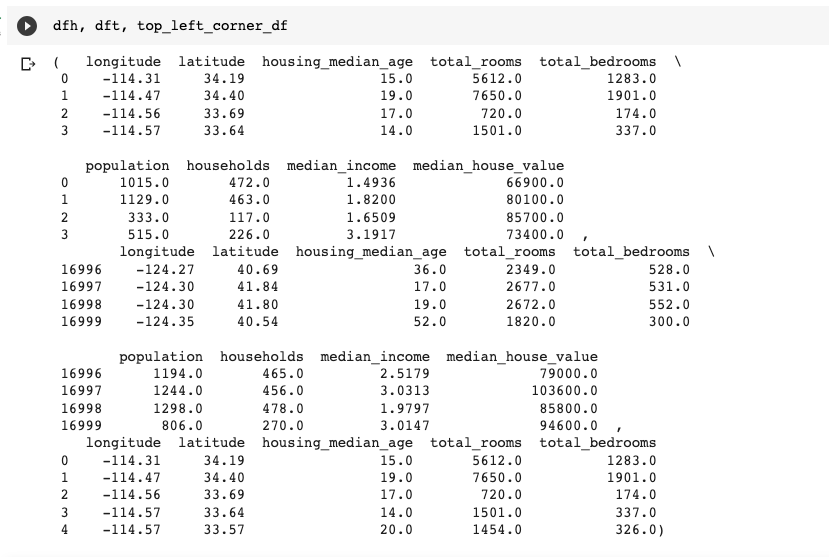

dfh, dft, top_left_corner_df

It would be better to display each dataframe alone. Use multiple cells to dispay them (one cell per dataframe)

```python
dfh
```

You will see the output as

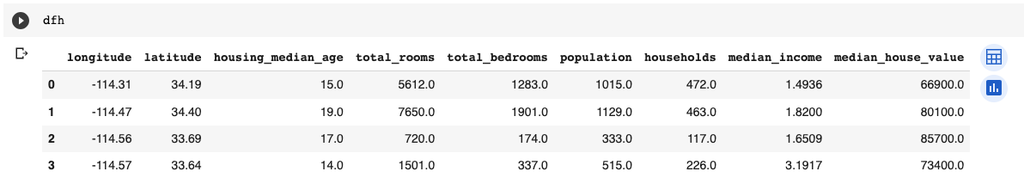

dfh

```python
dft
```

Similarly, dft will be displayed as:

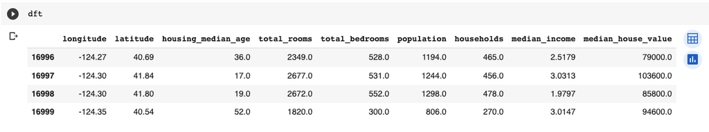

dft

```python
top_left_corner_df
```

- Extracting columns

```python
col_set = df.iloc[:, 5:9]
col_set
```

This code extracts columns 6, 7, 8, 9 assuming the first column is numbered 1 not as the python index 0.

For columns that are not in the same range, we separate the columns indexes with a comma.

```python
cols_set2 = df[df.columns[[5, 6, 8]]][:]
cols_set2
```

- Extracting rows

```python
# TODO: write the code to extract ROWS 11, 13, and 15 from the dataframe.
```

You can use the code:

```python
rows_set2 = df.iloc[[10, 12, 14], ]
rows_set2
```

Note that Python starts the index from 0.

- Extracting rows that satisfy a specific condition

```python
df.loc[(df['total_rooms'] > 5000).values, ['longitude', 'latitude', 'total_rooms',  'median_house_value']]
```

Another way

```python
df.iloc[(df['total_rooms'] > 5000).values, [0, 1, 3, 8]]
```

**Profiling the dataframes**

- Displaying the names of the attributes

```python
# TODO: print the names of the columns (attributes) of the dataframe.
```

You can access the name of the attributes using `df.columns`

```python
df.columns
```

OR

```python
for column in df.columns:
  print(column)
```

- Displaying the datatype of each column.

```python
dataTypeSeries = df.dtypes
for col_idx in range(len(df.columns)):
    print(df.columns[col_idx], 'has type (', dataTypeSeries[col_idx], ')')
```

- Displaying the names of the columns and the number of unique values in each column

```python
for col in  df.columns:
    print(col, ' has (', len(df[col].unique()), ') unique values')
```

- displaying quantities of interest such as `min`, `max`, …

```python
# TODO: print the min, max, average and standard deviation of the attributes with numerical datatype
```

```python
dataTypeSeries = df.dtypes
for col_idx in range(len(df.columns)):
       if (not (dataTypeSeries[col_idx] == 'object')):
            print(df.columns[col_idx], 'has Min = ', df[df.columns[col_idx]].min(),
                  'Max = ', df[df.columns[col_idx]].max(),
                  'Average = ', df[df.columns[col_idx]].mean(),
                  'Standard Deviation = ', df[df.columns[col_idx]].std())
```

- counting the missing values

```python
# TODO: print the name of each column in the dataframe and
#    the number of missing values in that column.

s = df['longitude'].isnull()
s.sum()
```

You can use the following code:

```python
for column in df.columns:
  s = df[column].isnull().sum()
  print(column, 'has (', s, ') missing values')
```

You may try another dataset such as the movies dataset as this dataset is complete.